# Proje Rapor : Miray Mutlu 210401039

# Q1 : Problem tanımı:

Şirketimiz **Howling Fjord LTD ŞTİ AŞ**. Problemimiz *araç kiralama sektöründe faaliyet göstermek isteyenlerin kaç yaşında hangi yakıt kullanan araçlar tercih etmeleri gerektiğini buluyoruz*.

# Q2 : Proje Amacı

https://www.kaggle.com/datasets/kushleshkumar/cornell-car-rental-dataset/data) adli Kaggle veri setini kullanarak iş problemini *dataset içerisindeki araç tipi modeli yakıt tipi yaşı gibi özellikleri değerlendirmek* ve **bu data setten çıkan tabloları/grafikleri/istatistikleri olarak yorumlama** yaparak çözmeyi amaçlıyoruz. Bu sayede problemi azaltmayı / yok etmeyi ya da kar arttırımına katkıda bulunmayı planlıyoruz.

# Q3 : Veri seti keşifsel analizi

Veri seti Kaggle web sitesinden indirilmiştir ve **readr::read_csv()** fonksiyonu kullanılmıştır Veri boyutları aşağıdaki gibidir :

- Satir sayisi : 5851
- Satir sayisi : 15

Histogramlarda araçların yapım yılları, derecelendirmeleri ve yorum sayıları bulunuyor.

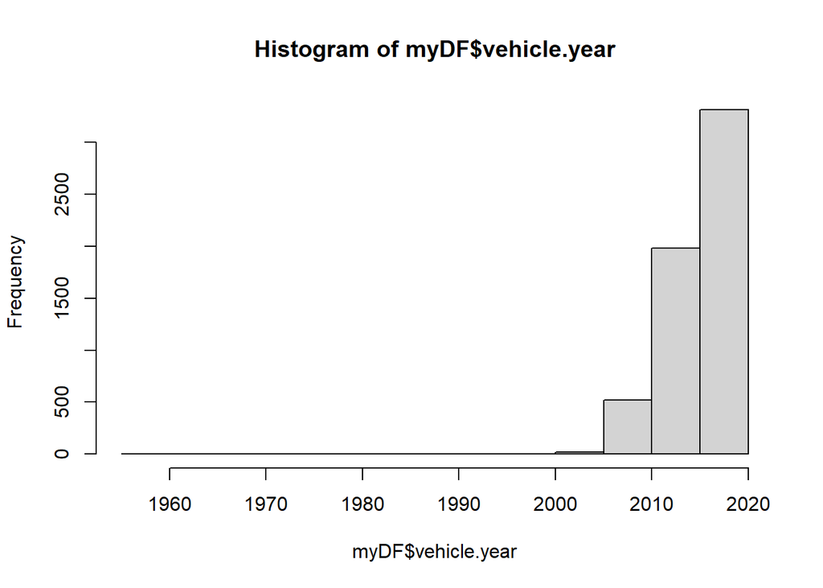

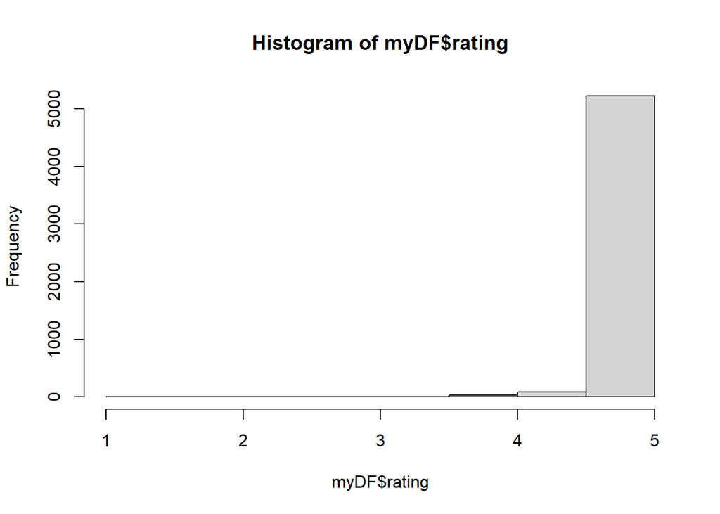

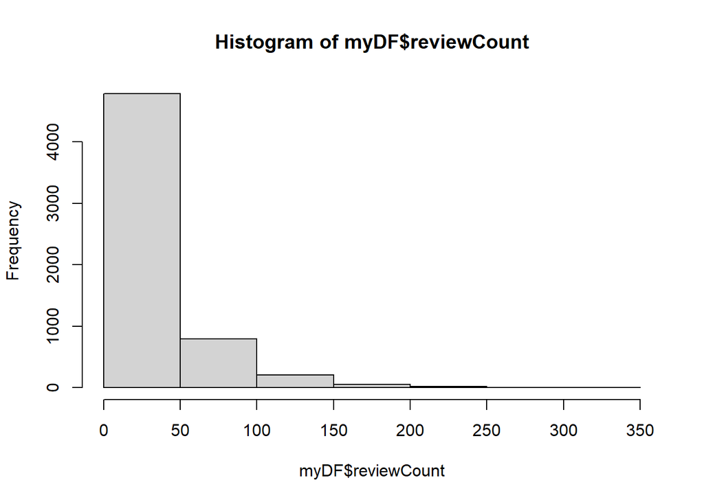

Yorum sayısı 150’den büyük olanlar filtrelenmiştir.

| fuelType | rating | renterTripsTaken | reviewCount | location.city | location.country | location.latitude | location.longitude | location.state | owner.id | rate.daily | vehicle.make | vehicle.model | vehicle.type | vehicle.year |
| --- | --- | --- | --- | --- | --- | --- | --- | --- | --- | --- | --- | --- | --- | --- |
| GASOLINE | 4.63 | 271 | 195 | Atlanta | US | 33.64836 | -84.45428 | GA | 507900 | 39 | Nissan | Versa Note | car | 2015 |
| GASOLINE | 4.95 | 230 | 199 | Nashville | US | 36.10223 | -86.64614 | TN | 311958 | 35 | Toyota | Camry | car | 2017 |
| GASOLINE | 4.97 | 246 | 173 | Brentwood | US | 35.96245 | -86.81749 | TN | 495552 | 52 | Chevrolet | Cruze | car | 2014 |
| HYBRID | 4.85 | 183 | 155 | Mentor | US | 41.67614 | -81.38811 | OH | 1092884 | 50 | Toyota | Camry Hybrid | car | 2014 |
| GASOLINE | 4.90 | 273 | 233 | Dallas | US | 32.82667 | -96.84763 | TX | 1582843 | 42 | Hyundai | Elantra | car | 2017 |
| GASOLINE | 4.97 | 215 | 176 | Dallas | US | 32.82667 | -96.84762 | TX | 1582843 | 42 | Kia | Forte | car | 2016 |
| GASOLINE | 4.83 | 246 | 204 | Dallas | US | 32.82611 | -96.84662 | TX | 1582843 | 40 | Toyota | Corolla | car | 2017 |
| GASOLINE | 4.89 | 216 | 174 | Dallas | US | 32.82651 | -96.84760 | TX | 1582843 | 40 | Ford | Fiesta | car | 2016 |
| GASOLINE | 4.78 | 269 | 219 | Dallas | US | 32.82651 | -96.84734 | TX | 1582843 | 38 | Nissan | Versa | car | 2017 |
| GASOLINE | 4.85 | 223 | 177 | Dallas | US | 32.82599 | -96.84844 | TX | 1582843 | 40 | Ford | Fiesta | car | 2016 |

[output cut: 68 more lines]

2015 sonrasında üretilen araçlar filtrelenmiştir

| fuelType | rating | renterTripsTaken | reviewCount | location.city | location.country | location.latitude | location.longitude | location.state | owner.id | rate.daily | vehicle.make | vehicle.model | vehicle.type | vehicle.year |
| --- | --- | --- | --- | --- | --- | --- | --- | --- | --- | --- | --- | --- | --- | --- |
| ELECTRIC | 5.00 | 13 | 12 | Seattle | US | 47.44911 | -122.30884 | WA | 12847615 | 135 | Tesla | Model X | suv | 2019 |
| ELECTRIC | 5.00 | 2 | 1 | Tijeras | US | 35.11106 | -106.27655 | NM | 15621242 | 190 | Tesla | Model X | suv | 2018 |
| GASOLINE | 5.00 | 21 | 20 | Albuquerque | US | 35.14973 | -106.71143 | NM | 9365496 | 75 | Ford | Mustang | car | 2018 |
| GASOLINE | 4.90 | 12 | 10 | Albuquerque | US | 35.18654 | -106.68648 | NM | 9536762 | 117 | Ford | Expedition | suv | 2018 |
| GASOLINE | 5.00 | 1 | 1 | Albuquerque | US | 35.06121 | -106.62941 | NM | 14893743 | 102 | Ford | Focus RS | car | 2016 |
| GASOLINE | 4.76 | 22 | 17 | Albuquerque | US | 35.11536 | -106.55691 | NM | 11389136 | 49 | Ford | EcoSport | suv | 2018 |
| GASOLINE | 5.00 | 11 | 7 | Albuquerque | US | 35.07855 | -106.49737 | NM | 9346980 | 88 | Volkswagen | Tiguan | suv | 2018 |
| GASOLINE | NA | 0 | 0 | Albuquerque | US | 35.11565 | -106.57881 | NM | 1889102 | 42 | Jeep | Cherokee | suv | 2018 |
| GASOLINE | 4.67 | 5 | 3 | Albuquerque | US | 35.04901 | -106.61736 | NM | 4112693 | 119 | Jeep | Wrangler JK | suv | 2018 |
| GASOLINE | 5.00 | 24 | 19 | Santa Fe | US | 35.59739 | -106.04087 | NM | 1603416 | 80 | Ford | Mustang | car | 2019 |

[output cut: 3303 more lines]

ARAÇLARIN YAKIT TÜKETİM TÜRLERİ

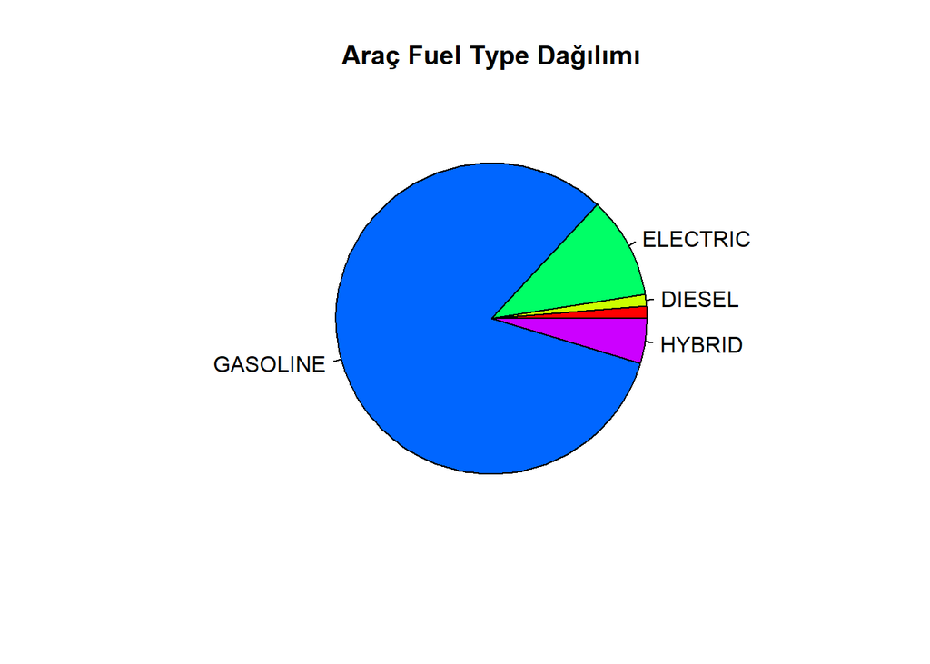

# Q4 : Veri seti ön işlemesi

Ön İşleme Raporu:

vehicle.model sütunu: Null değerleri silindi ve araç tipleri yazıldı.

location.state Sütunu: null değerleri silindi ve eyaletler yazıldı.

reviewCount sütunu: null değerler silindi ve sayıları yazıldı.

| vehicle.model | location.state | vehicle.type | fuelType | reviewCount |
| --- | --- | --- | --- | --- |
| Sentra | GA | car | GASOLINE | 146 |
| Cruze | TN | car | GASOLINE | 138 |
| Camry | TN | car | GASOLINE | 199 |
| Versa | TX | car | GASOLINE | 139 |
| Elantra | TX | car | GASOLINE | 233 |
| Forte | TX | car | GASOLINE | 176 |
| Corolla | TX | car | GASOLINE | 204 |
| Fiesta | TX | car | GASOLINE | 174 |
| Versa | TX | car | GASOLINE | 219 |
| Fiesta | TX | car | GASOLINE | 177 |

[output cut: 42 more lines]

# Q5 : Veri Mühendisliği

Filtrelerden geçip oluşan sentetik verimizin yakıt türü grafiği:

```
## veri
## electric gasoline   hybrid
##        6       45        1
```

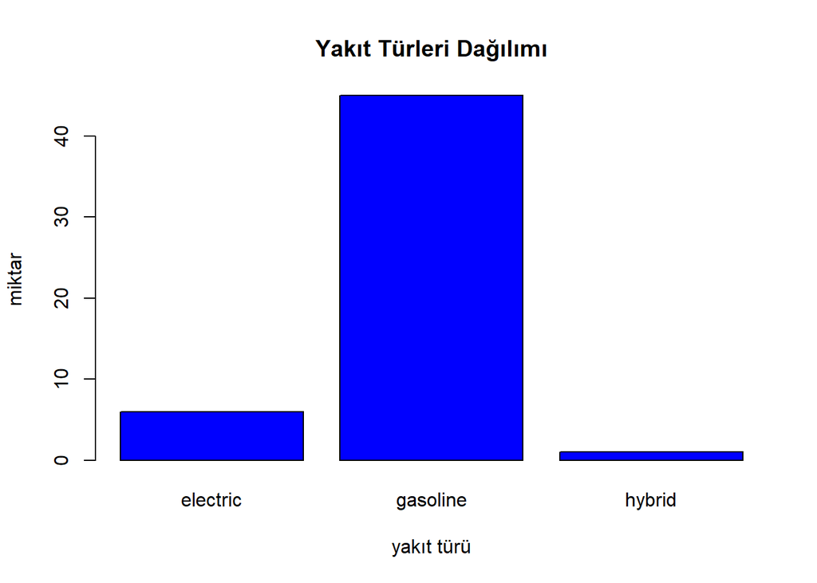

Tablonun pasta grafiğinde gösterimi:

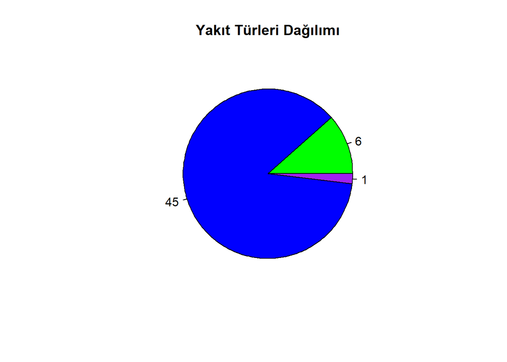